# index

**Collaborators: Can Li, Richard Han**

[figure not shown]

### Introduction

The primary purpose of this project is to guide you through the entire data science pipeline. We have chosen to analyze how a GPU's release date and specifications impact its manufacturer's suggested retail price (MSRP). By doing so, we aim to capture the relationship between the release date, specifications, and price of GPUs to predict future GPU specifications based on their release date and price. This ensures that buyers get a fair deal and allows us to visualize the overall trend of price-to-performance over time.

Why are GPUs so important? GPU stands for graphics processing unit, and it is hardware designed to handle large amounts of parallel processing. This makes it essential for tasks requiring intensive computational power, such as rendering complex graphics, machine learning, and scientific simulations. GPUs are critical to individual consumers for gaming, video editing, content creation, and companies utilizing their power for machine learning and deep learning. By analyzing and predicting the future prices of GPUS as well as how powerful they may become, it allows people to see if a new line of GPUs fits the general price-to-performance trend and, from that, make the decision to wait for prices to go down, buy an older generation GPU, or wait for the next generation depending on their needs. Choosing a cost-effective GPU is essential for larger companies requiring hundreds to tens of thousands of GPUs and general consumers.

### Data Collection

```python
from bs4 import BeautifulSoup
import requests
import pandas as pd
import numpy as np
import time
import datetime
from dateutil import parser
import re
import matplotlib.pyplot as plt
from mpl_toolkits import mplot3d
from mpl_toolkits.mplot3d import Axes3D
from sklearn.linear_model import LinearRegression
```

The first and most important thing you must do in the data science pipeline is get reliable data. When looking for the information we needed, finding sources with GPU specifications and release dates was quite easy. However, most of these sources lacked the release MSRP of the GPUs, as that is not a metric many people look into. However, we found a website containing all the information we needed at TechPowerUp. **TechPowerUp GPU Database**

```python
# data from 2024
url = 'https://www.techpowerup.com/gpu-specs/?released=2024&workstation=No&igp=No&sort=name'
html = requests.get(url).content
soup = BeautifulSoup(html, 'html.parser')
table = soup.find("table", class_="processors")
print(table)
```

[output not shown]

[output cut: 93 more lines]

[output not shown]

```python
columnsNames = table.findAll("th")
columnsNames = [name.text.lower() for name in columnsNames]

features = []
for i in range(1,9):
    features.append(columnsNames[i])

df = pd.DataFrame(columns = features)
```

The webpage contains a smaller irrelevant table and rows of section titles, so we filtered out the rows that don't include all eight features.

```python
columnsData = table.findAll("tr")
num = len(features)

for row in columnsData:
    rowsData = row.findAll("td")

    if(len(rowsData) == num):
        df.loc[len(df)] = [(data.text).strip() for data in rowsData]

df.head(10)
```

|  | product name | gpu chip | released | bus | memory | gpu clock | memory clock | shaders / tmus / rops |
| --- | --- | --- | --- | --- | --- | --- | --- | --- |
| 0 | Radeon RX 7600 XT | Navi 33 | Jan 8th, 2024 | PCIe 4.0 x8 | 16 GB, GDDR6, 128 bit | 1980 MHz | 2250 MHz | 2048 / 128 / 64 |
| 1 | GeForce RTX 3050 6 GB | GA107 | Feb 2nd, 2024 | PCIe 4.0 x8 | 6 GB, GDDR6, 96 bit | 1042 MHz | 1750 MHz | 2304 / 72 / 32 |
| 2 | GeForce RTX 4060 AD106 | AD106 | Apr 2024 | PCIe 4.0 x8 | 8 GB, GDDR6, 128 bit | 1830 MHz | 2125 MHz | 3072 / 96 / 48 |
| 3 | GeForce RTX 4060 Ti AD104 | AD104 | Apr 2024 | PCIe 4.0 x8 | 8 GB, GDDR6, 128 bit | 2310 MHz | 2250 MHz | 4352 / 136 / 48 |
| 4 | GeForce RTX 4070 AD103 | AD103 | Mar 2024 | PCIe 4.0 x16 | 12 GB, GDDR6X, 192 bit | 1920 MHz | 1313 MHz | 5888 / 184 / 64 |
| 5 | GeForce RTX 4070 SUPER | AD104 | Jan 8th, 2024 | PCIe 4.0 x16 | 12 GB, GDDR6X, 192 bit | 1980 MHz | 1313 MHz | 7168 / 224 / 80 |
| 6 | GeForce RTX 4070 Ti SUPER | AD103 | Jan 8th, 2024 | PCIe 4.0 x16 | 16 GB, GDDR6X, 256 bit | 2340 MHz | 1313 MHz | 8448 / 264 / 96 |
| 7 | GeForce RTX 4080 SUPER | AD103 | Jan 8th, 2024 | PCIe 4.0 x16 | 16 GB, GDDR6X, 256 bit | 2295 MHz | 1438 MHz | 10240 / 320 / 112 |

TechPowerUp limits the amount of information it displays in its tables, so to get all the data that we needed, we sorted the GPU data by year of release and scrapped the HTTP tables that contained the product name, GPU chip, release date, bus, memory, GPU clock, memory clock, and shader, TMU, and ROP cores. The GPU chip is the name of the physical chip in the GPU. The bus refers to the type and speed of the interface through which the GPU communicates with the rest of the system. The memory contains information about the amount, type, and width of the data path between the GPU and the VRAM in the card. The GPU clock is the speed at which the GPU's processor core operates. It's usually measured in megahertz (MHz) or gigahertz (GHz). The GPU clock speed determines how quickly the GPU can process data and execute instructions. The memory clock is the speed at which the memory on the graphics card operates. Finally, the shader, TMU, and ROP cores number the amount of Shader cores, Texture Mapping Units (TMUs), and Raster Operations Pipelines (ROPs). Shader cores are responsible for executing programmable shaders, which are small programs that process vertices and pixels in 3D graphics rendering. TMUs are accountable for applying textures to 3D objects during rendering. ROPs are responsible for the final stage of the rendering pipeline, where the pixels are processed before being written to the frame buffer.

The scraping works for individual years, but due to the website's anti-DDOS attack features prevent rapid or continuous requests for various web pages. This prevents the loop in the code from working correctly, so we scrapped each year separately and compiled them together.

```python
# we will scrap the data from 2004 to 2024
# since we already scrapped the data from 2024,
# we will stop at 2023
end = 2024 + 1      # make it inclusive
start = 2004 - 1    # make it inclusive

for year in range(end, start, -1):
    # prevent the website from triggering DDOS Alert
    time.sleep(60)

    url = 'https://www.techpowerup.com/gpu-specs/?released={year}&workstation=No&igp=No&sort=name'
    html = requests.get(url).content
    soup = BeautifulSoup(html, 'html.parser')
    table = soup.find("table", class_="processors")

    columnsData = table.findAll("tr")

    for row in columnsData:
        rowsData = row.findAll("td")
        print(rowsData)
        if(len(rowsData) == num):
            df.loc[len(df)] = [data.text for data in rowsData]
```

After we scrape the initial data from TechPowerUp, we need to add the release MSPR. TechPowerUp has this information, but it is not presented in the tables. Instead, it is listed on the individual web pages of the GPUs. We manually scrapped each initial price for the GPUs when available.

```python
# Save the DataFrame to a CSV file
df.to_csv('data.csv', index=False)
```

The csv file can be found **[here](https://masksenpai.github.io/GPU_2004-2024.csv)**.

### Data Processing

```python
# Read the CSV file
# Data gathered from techpowerup.com GPU Data Base
df = pd.read_csv("GPU_2004-2024.csv")
df.head(10)
```

|  | Product Name | GPU Chip | Released | Bus | Memory | GPU clock | Memory clock | Shaders / TMUs / ROPs | MSRP |
| --- | --- | --- | --- | --- | --- | --- | --- | --- | --- |
| 0 | Radeon 9000 PRO Mac Edition | RV250 | Mar 14th, 2004 | AGP 4x | 64 MB, DDR, 128 bit | 275 MHz | 275 MHz | 4 / 1 / 4 / 4 | NaN |
| 1 | Radeon 9250 PCI | RV280 | Mar 1st, 2004 | PCI | 128 MB, DDR, 64 bit | 240 MHz | 200 MHz | 4 / 1 / 4 / 4 | NaN |
| 2 | Radeon 9250 | RV280 | Mar 1st, 2004 | AGP 8x | 64 MB, DDR, 64 bit | 240 MHz | 200 MHz | 4 / 1 / 4 / 4 | NaN |
| 3 | Radeon 9800 PRO Mac Edition | R360 | Mar 4th, 2004 | AGP Pro 8x | 128 MB, DDR, 256 bit | 378 MHz | 338 MHz | 8 / 4 / 8 / 8 | NaN |
| 4 | Radeon 9800 XT Mac Edition | R360 | Mar 14th, 2004 | AGP Pro 8x | 256 MB, DDR, 256 bit | 412 MHz | 365 MHz | 8 / 4 / 8 / 8 | NaN |
| 5 | Radeon X300 SE | RV370 | Sep 1st, 2004 | PCIe 1.0 x16 | 64 MB, DDR, 64 bit | 325 MHz | 200 MHz | 4 / 2 / 4 / 4 | NaN |
| 6 | Radeon X300 LE | RV370 | Sep 1st, 2004 | PCIe 1.0 x16 | 64 MB, DDR, 128 bit | 325 MHz | 200 MHz | 4 / 2 / 4 / 4 | NaN |
| 7 | Radeon X300 | RV370 | Sep 1st, 2004 | PCIe 1.0 x16 | 64 MB, DDR, 128 bit | 375 MHz | 200 MHz | 4 / 2 / 4 / 4 | NaN |
| 8 | Radeon X600 SE | RV370 | Sep 1st, 2004 | PCIe 1.0 x16 | 128 MB, DDR, 64 bit | 325 MHz | 250 MHz | 4 / 2 / 4 / 4 | NaN |
| 9 | Radeon X600 | RV370 | Sep 1st, 2004 | PCIe 1.0 x16 | 256 MB, DDR, 128 bit | 400 MHz | 250 MHz | 4 / 2 / 4 / 4 | NaN |

Since we are using the official MSRP as one of the independent variables, we will drop the GPUs without an official MSRP. Some GPUs have official MSRP but were never released; we will also drop those GPUs since we cannot calculate the inflated price without a date.

```python
# Delete all the GPUs that doesn't have a MSRP (Manufacturer’s suggested retail price)
df.dropna(subset=[df.columns[-1]], inplace=True)

# Delete all the GPUs that are not realsed
df.drop(df[df['Released'] == "Never Released"].index, inplace=True)

df.reset_index(drop=True, inplace=True)
df.head(10)
```

|  | Product Name | GPU Chip | Released | Bus | Memory | GPU clock | Memory clock | Shaders / TMUs / ROPs | MSRP |
| --- | --- | --- | --- | --- | --- | --- | --- | --- | --- |
| 0 | Radeon X700 PRO | RV410 | Sep 1st, 2004 | PCIe 1.0 x16 | 128 MB, GDDR3, 128 bit | 425 MHz | 430 MHz | 8 / 6 / 8 / 8 | 179.0 |
| 1 | Radeon X700 XT | RV410 | Sep 1st, 2004 | PCIe 1.0 x16 | 128 MB, GDDR3, 128 bit | 475 MHz | 525 MHz | 8 / 6 / 8 / 8 | 199.0 |
| 2 | Radeon X800 | R430 | Dec 1st, 2004 | PCIe 1.0 x16 | 256 MB, DDR, 256 bit | 400 MHz | 350 MHz | 12 / 6 / 12 / 12 | 249.0 |
| 3 | Radeon X800 PRO | R423 | May 1st, 2004 | PCIe 1.0 x16 | 256 MB, GDDR3, 256 bit | 475 MHz | 450 MHz | 12 / 6 / 12 / 12 | 399.0 |
| 4 | Radeon X800 XL | R430 | Dec 1st, 2004 | PCIe 1.0 x16 | 256 MB, GDDR3, 256 bit | 400 MHz | 490 MHz | 16 / 6 / 16 / 16 | 349.0 |
| 5 | Radeon X800 XT | R423 | Dec 1st, 2004 | PCIe 1.0 x16 | 256 MB, GDDR3, 256 bit | 500 MHz | 500 MHz | 16 / 6 / 16 / 16 | 499.0 |
| 6 | Radeon X800 XT Platinum | R423 | Mar 1st, 2004 | PCIe 1.0 x16 | 256 MB, GDDR3, 256 bit | 520 MHz | 560 MHz | 16 / 6 / 16 / 16 | 499.0 |
| 7 | Radeon X850 PRO | R480 | Dec 1st, 2004 | PCIe 1.0 x16 | 256 MB, GDDR3, 256 bit | 507 MHz | 520 MHz | 12 / 6 / 12 / 12 | 279.0 |
| 8 | Radeon X850 XT | R480 | Dec 1st, 2004 | PCIe 1.0 x16 | 256 MB, GDDR3, 256 bit | 520 MHz | 540 MHz | 16 / 6 / 16 / 16 | 499.0 |
| 9 | Radeon X850 XT Platinum | R480 | Dec 21st, 2004 | PCIe 1.0 x16 | 256 MB, GDDR3, 256 bit | 540 MHz | 590 MHz | 16 / 6 / 16 / 16 | 549.0 |

Transform the release date data from string into date objects.

```python
# Create a realsed date coulmn to store the date data in date object
df["Released Date"] = datetime.datetime(2024, 5, 1)

for i in range(len(df)):
    dt = parser.parse(df.iloc[i]["Released"])
    df.loc[i, "Released Date"] = datetime.datetime(dt.year, dt.month, dt.day)

df.drop('Released', axis=1, inplace=True)

df.head(10)
```

|  | Product Name | GPU Chip | Bus | Memory | GPU clock | Memory clock | Shaders / TMUs / ROPs | MSRP | Released Date |
| --- | --- | --- | --- | --- | --- | --- | --- | --- | --- |
| 0 | Radeon X700 PRO | RV410 | PCIe 1.0 x16 | 128 MB, GDDR3, 128 bit | 425 MHz | 430 MHz | 8 / 6 / 8 / 8 | 179.0 | 2004-09-01 |
| 1 | Radeon X700 XT | RV410 | PCIe 1.0 x16 | 128 MB, GDDR3, 128 bit | 475 MHz | 525 MHz | 8 / 6 / 8 / 8 | 199.0 | 2004-09-01 |
| 2 | Radeon X800 | R430 | PCIe 1.0 x16 | 256 MB, DDR, 256 bit | 400 MHz | 350 MHz | 12 / 6 / 12 / 12 | 249.0 | 2004-12-01 |
| 3 | Radeon X800 PRO | R423 | PCIe 1.0 x16 | 256 MB, GDDR3, 256 bit | 475 MHz | 450 MHz | 12 / 6 / 12 / 12 | 399.0 | 2004-05-01 |
| 4 | Radeon X800 XL | R430 | PCIe 1.0 x16 | 256 MB, GDDR3, 256 bit | 400 MHz | 490 MHz | 16 / 6 / 16 / 16 | 349.0 | 2004-12-01 |
| 5 | Radeon X800 XT | R423 | PCIe 1.0 x16 | 256 MB, GDDR3, 256 bit | 500 MHz | 500 MHz | 16 / 6 / 16 / 16 | 499.0 | 2004-12-01 |
| 6 | Radeon X800 XT Platinum | R423 | PCIe 1.0 x16 | 256 MB, GDDR3, 256 bit | 520 MHz | 560 MHz | 16 / 6 / 16 / 16 | 499.0 | 2004-03-01 |
| 7 | Radeon X850 PRO | R480 | PCIe 1.0 x16 | 256 MB, GDDR3, 256 bit | 507 MHz | 520 MHz | 12 / 6 / 12 / 12 | 279.0 | 2004-12-01 |
| 8 | Radeon X850 XT | R480 | PCIe 1.0 x16 | 256 MB, GDDR3, 256 bit | 520 MHz | 540 MHz | 16 / 6 / 16 / 16 | 499.0 | 2004-12-01 |
| 9 | Radeon X850 XT Platinum | R480 | PCIe 1.0 x16 | 256 MB, GDDR3, 256 bit | 540 MHz | 590 MHz | 16 / 6 / 16 / 16 | 549.0 | 2004-12-21 |

We needed to adjust the MSRP for inflation. To do this, we accessed this inflation **[API](https://www.statbureau.org)** (https://www.statbureau.org) from StatBeauru. We set it so the adjusted release price would be in May 2024 USD.

```python
# https://www.statbureau.org
# Using APIs to get the inflation USD price (convert to 05/01/2024)
def calculate_inflation_price(start_date, end_date, start_price):
    url = 'https://www.statbureau.org/calculate-inflation-price-jsonp?jsoncallback=?'
    params = {
        'country': 'united-states',
        'start': start_date,
        'end': end_date,
        'amount': start_price,
        'format': True
    }

    response = requests.get(url, params=params)
    data = response.text

    # delete all the non-integer characters in the str,
    # so it can be converted to a float variable later
    end_price = re.sub(r'[^0-9.]', '', data)
    return float(end_price)

# MSRP adjusted to the inflated price to 2024/05/01
df["Inflation MSRP"] = np.nan
end_date = "2024/5/1"

for i in range(len(df)):
    df.loc[i, "Inflation MSRP"] = calculate_inflation_price(df.loc[i, "Released Date"].strftime('%Y/%m/%d'), end_date, df.loc[i, "MSRP"])

df.drop('MSRP', axis=1, inplace=True)
df.head(10)
```

|  | Product Name | GPU Chip | Bus | Memory | GPU clock | Memory clock | Shaders / TMUs / ROPs | Released Date | Inflation MSRP |
| --- | --- | --- | --- | --- | --- | --- | --- | --- | --- |
| 0 | Radeon X700 PRO | RV410 | PCIe 1.0 x16 | 128 MB, GDDR3, 128 bit | 425 MHz | 430 MHz | 8 / 6 / 8 / 8 | 2004-09-01 | 246.04 |
| 1 | Radeon X700 XT | RV410 | PCIe 1.0 x16 | 128 MB, GDDR3, 128 bit | 475 MHz | 525 MHz | 8 / 6 / 8 / 8 | 2004-09-01 | 273.53 |
| 2 | Radeon X800 | R430 | PCIe 1.0 x16 | 256 MB, DDR, 256 bit | 400 MHz | 350 MHz | 12 / 6 / 12 / 12 | 2004-12-01 | 339.57 |
| 3 | Radeon X800 PRO | R423 | PCIe 1.0 x16 | 256 MB, GDDR3, 256 bit | 475 MHz | 450 MHz | 12 / 6 / 12 / 12 | 2004-05-01 | 552.81 |
| 4 | Radeon X800 XL | R430 | PCIe 1.0 x16 | 256 MB, GDDR3, 256 bit | 400 MHz | 490 MHz | 16 / 6 / 16 / 16 | 2004-12-01 | 475.94 |
| 5 | Radeon X800 XT | R423 | PCIe 1.0 x16 | 256 MB, GDDR3, 256 bit | 500 MHz | 500 MHz | 16 / 6 / 16 / 16 | 2004-12-01 | 680.51 |
| 6 | Radeon X800 XT Platinum | R423 | PCIe 1.0 x16 | 256 MB, GDDR3, 256 bit | 520 MHz | 560 MHz | 16 / 6 / 16 / 16 | 2004-03-01 | 698.05 |
| 7 | Radeon X850 PRO | R480 | PCIe 1.0 x16 | 256 MB, GDDR3, 256 bit | 507 MHz | 520 MHz | 12 / 6 / 12 / 12 | 2004-12-01 | 380.48 |
| 8 | Radeon X850 XT | R480 | PCIe 1.0 x16 | 256 MB, GDDR3, 256 bit | 520 MHz | 540 MHz | 16 / 6 / 16 / 16 | 2004-12-01 | 680.51 |
| 9 | Radeon X850 XT Platinum | R480 | PCIe 1.0 x16 | 256 MB, GDDR3, 256 bit | 540 MHz | 590 MHz | 16 / 6 / 16 / 16 | 2004-12-21 | 748.69 |

We will sort the GPUs by release date, setting the oldest GPU to month 0 and using it as a reference point to calculate the perspective month value of the rest of the GPUs. This will allow us to visualize the data more easily.

```python
# Sort the data by released dates
df = df.sort_values(by = 'Released Date', ascending=True)
df.reset_index(drop=True, inplace=True)

df.reset_index(drop=True, inplace=True)

# Set the base line date (earlist date in the data)
base = df.loc[0, "Released Date"]

# Return the months that has passed since the base line date
def get_months(target):
    return (target.year - base.year) * 12 + (target.month - base.month)

df["Month"] = 0

for i in range(len(df)):
    df.loc[i, "Month"] = get_months(df.loc[i, "Released Date"])

df.head(10)
```

|  | Product Name | GPU Chip | Bus | Memory | GPU clock | Memory clock | Shaders / TMUs / ROPs | Released Date | Inflation MSRP | Month |
| --- | --- | --- | --- | --- | --- | --- | --- | --- | --- | --- |
| 0 | Radeon X800 XT Platinum | R423 | PCIe 1.0 x16 | 256 MB, GDDR3, 256 bit | 520 MHz | 560 MHz | 16 / 6 / 16 / 16 | 2004-03-01 | 698.05 | 0 |
| 1 | GeForce 6800 Ultra DDL | NV40 | AGP Pro 8x | 256 MB, GDDR3, 256 bit | 400 MHz | 550 MHz | 16 / 6 / 16 / 16 | 2004-04-14 | 832.57 | 1 |
| 2 | GeForce 6800 GT DDL | NV40 | AGP Pro 8x | 256 MB, GDDR3, 256 bit | 350 MHz | 500 MHz | 16 / 6 / 16 / 16 | 2004-04-14 | 693.58 | 1 |
| 3 | Radeon X800 PRO | R423 | PCIe 1.0 x16 | 256 MB, GDDR3, 256 bit | 475 MHz | 450 MHz | 12 / 6 / 12 / 12 | 2004-05-01 | 552.81 | 2 |
| 4 | GeForce 6800 Ultra | NV45 | PCIe 1.0 x16 | 256 MB, GDDR3, 256 bit | 425 MHz | 550 MHz | 16 / 6 / 16 / 16 | 2004-07-26 | 685.17 | 4 |
| 5 | GeForce 6600 GT | NV43 | PCIe 1.0 x16 | 128 MB, GDDR3, 128 bit | 500 MHz | 500 MHz | 8 / 3 / 8 / 4 | 2004-08-12 | 273.68 | 5 |
| 6 | Radeon X700 PRO | RV410 | PCIe 1.0 x16 | 128 MB, GDDR3, 128 bit | 425 MHz | 430 MHz | 8 / 6 / 8 / 8 | 2004-09-01 | 246.04 | 6 |
| 7 | Radeon X700 XT | RV410 | PCIe 1.0 x16 | 128 MB, GDDR3, 128 bit | 475 MHz | 525 MHz | 8 / 6 / 8 / 8 | 2004-09-01 | 273.53 | 6 |
| 8 | All-In-Wonder X800 GT | R430 | PCIe 1.0 x16 | 128 MB, GDDR3, 128 bit | 398 MHz | 492 MHz | 8 / 6 / 8 / 8 | 2004-09-21 | 342.26 | 6 |
| 9 | All-In-Wonder X800 XT | R420 | AGP 8x | 256 MB, GDDR3, 256 bit | 500 MHz | 500 MHz | 16 / 6 / 16 / 16 | 2004-09-21 | 246.04 | 6 |

For the shader, TMU, and ROP cores, we noticed that some of the older GPUs had four numbers instead of 3; upon further investigation, that was because they had two types of shader cores. We chose to make the shader core number for those GPUs a combination of those sub-shader cores.

```python
# Spliting Shaders/TMUs/ROPs into three different columns
df["Shaders"] = 0
df["TMUs"] = 0
df["ROPs"] = 0

for i in range(len(df)):
    s = df.loc[i, "Shaders / TMUs / ROPs"].replace("/", "")
    all_results = s.split()

    temp = 0
    if len(all_results) == 4:
        temp = int(all_results.pop(0))

    df.loc[i, "Shaders"] = int(all_results[0]) + temp
    df.loc[i, "TMUs"] = int(all_results[1])
    df.loc[i, "ROPs"] = int(all_results[2])

df.drop('Shaders / TMUs / ROPs', axis=1, inplace=True)
df.head(10)
```

|  | Product Name | GPU Chip | Bus | Memory | GPU clock | Memory clock | Released Date | Inflation MSRP | Month | Shaders | TMUs | ROPs |
| --- | --- | --- | --- | --- | --- | --- | --- | --- | --- | --- | --- | --- |
| 0 | Radeon X800 XT Platinum | R423 | PCIe 1.0 x16 | 256 MB, GDDR3, 256 bit | 520 MHz | 560 MHz | 2004-03-01 | 698.05 | 0 | 22 | 16 | 16 |
| 1 | GeForce 6800 Ultra DDL | NV40 | AGP Pro 8x | 256 MB, GDDR3, 256 bit | 400 MHz | 550 MHz | 2004-04-14 | 832.57 | 1 | 22 | 16 | 16 |
| 2 | GeForce 6800 GT DDL | NV40 | AGP Pro 8x | 256 MB, GDDR3, 256 bit | 350 MHz | 500 MHz | 2004-04-14 | 693.58 | 1 | 22 | 16 | 16 |
| 3 | Radeon X800 PRO | R423 | PCIe 1.0 x16 | 256 MB, GDDR3, 256 bit | 475 MHz | 450 MHz | 2004-05-01 | 552.81 | 2 | 18 | 12 | 12 |
| 4 | GeForce 6800 Ultra | NV45 | PCIe 1.0 x16 | 256 MB, GDDR3, 256 bit | 425 MHz | 550 MHz | 2004-07-26 | 685.17 | 4 | 22 | 16 | 16 |
| 5 | GeForce 6600 GT | NV43 | PCIe 1.0 x16 | 128 MB, GDDR3, 128 bit | 500 MHz | 500 MHz | 2004-08-12 | 273.68 | 5 | 11 | 8 | 4 |
| 6 | Radeon X700 PRO | RV410 | PCIe 1.0 x16 | 128 MB, GDDR3, 128 bit | 425 MHz | 430 MHz | 2004-09-01 | 246.04 | 6 | 14 | 8 | 8 |
| 7 | Radeon X700 XT | RV410 | PCIe 1.0 x16 | 128 MB, GDDR3, 128 bit | 475 MHz | 525 MHz | 2004-09-01 | 273.53 | 6 | 14 | 8 | 8 |
| 8 | All-In-Wonder X800 GT | R430 | PCIe 1.0 x16 | 128 MB, GDDR3, 128 bit | 398 MHz | 492 MHz | 2004-09-21 | 342.26 | 6 | 14 | 8 | 8 |
| 9 | All-In-Wonder X800 XT | R420 | AGP 8x | 256 MB, GDDR3, 256 bit | 500 MHz | 500 MHz | 2004-09-21 | 246.04 | 6 | 22 | 16 | 16 |

```python
# Creating a new column for Memory, and coverting the unit to MB
df["Memory (in MB)"] = 0

for i in range(len(df)):
    s = df.loc[i, "Memory"]

    result = re.match(r'(\d+) ((MB)|(GB))', s)

    df.loc[i, "Memory (in MB)"] = int(result[1])

    if result[2] == 'GB':
        df.loc[i, "Memory (in MB)"] *= 1000

df.drop('Memory', axis=1, inplace=True)
df.head(10)
```

|  | Product Name | GPU Chip | Bus | GPU clock | Memory clock | Released Date | Inflation MSRP | Month | Shaders | TMUs | ROPs | Memory (in MB) |
| --- | --- | --- | --- | --- | --- | --- | --- | --- | --- | --- | --- | --- |
| 0 | Radeon X800 XT Platinum | R423 | PCIe 1.0 x16 | 520 MHz | 560 MHz | 2004-03-01 | 698.05 | 0 | 22 | 16 | 16 | 256 |
| 1 | GeForce 6800 Ultra DDL | NV40 | AGP Pro 8x | 400 MHz | 550 MHz | 2004-04-14 | 832.57 | 1 | 22 | 16 | 16 | 256 |
| 2 | GeForce 6800 GT DDL | NV40 | AGP Pro 8x | 350 MHz | 500 MHz | 2004-04-14 | 693.58 | 1 | 22 | 16 | 16 | 256 |
| 3 | Radeon X800 PRO | R423 | PCIe 1.0 x16 | 475 MHz | 450 MHz | 2004-05-01 | 552.81 | 2 | 18 | 12 | 12 | 256 |
| 4 | GeForce 6800 Ultra | NV45 | PCIe 1.0 x16 | 425 MHz | 550 MHz | 2004-07-26 | 685.17 | 4 | 22 | 16 | 16 | 256 |
| 5 | GeForce 6600 GT | NV43 | PCIe 1.0 x16 | 500 MHz | 500 MHz | 2004-08-12 | 273.68 | 5 | 11 | 8 | 4 | 128 |
| 6 | Radeon X700 PRO | RV410 | PCIe 1.0 x16 | 425 MHz | 430 MHz | 2004-09-01 | 246.04 | 6 | 14 | 8 | 8 | 128 |
| 7 | Radeon X700 XT | RV410 | PCIe 1.0 x16 | 475 MHz | 525 MHz | 2004-09-01 | 273.53 | 6 | 14 | 8 | 8 | 128 |
| 8 | All-In-Wonder X800 GT | R430 | PCIe 1.0 x16 | 398 MHz | 492 MHz | 2004-09-21 | 342.26 | 6 | 14 | 8 | 8 | 128 |
| 9 | All-In-Wonder X800 XT | R420 | AGP 8x | 500 MHz | 500 MHz | 2004-09-21 | 246.04 | 6 | 22 | 16 | 16 | 256 |

GPU Clock and Memory Clock are store as Strings, so we have to convert them into integers.

```python
# Transfer GPU and Memory clock data into int
df["GPU Clock (in MHz)"] = 0
df["Memory Clock (in MHz)"] = 0

for i in range(len(df)):
    df.loc[i, "GPU Clock (in MHz)"] = int(df.loc[i, "GPU clock"].replace(" MHz", ""))
    df.loc[i, "Memory Clock (in MHz)"] = int(df.loc[i, "Memory clock"].replace(" MHz", ""))

df.drop('GPU clock', axis=1, inplace=True)
df.drop('Memory clock', axis=1, inplace=True)
df.head(10)
```

|  | Product Name | GPU Chip | Bus | Released Date | Inflation MSRP | Month | Shaders | TMUs | ROPs | Memory (in MB) | GPU Clock (in MHz) | Memory Clock (in MHz) |
| --- | --- | --- | --- | --- | --- | --- | --- | --- | --- | --- | --- | --- |
| 0 | Radeon X800 XT Platinum | R423 | PCIe 1.0 x16 | 2004-03-01 | 698.05 | 0 | 22 | 16 | 16 | 256 | 520 | 560 |
| 1 | GeForce 6800 Ultra DDL | NV40 | AGP Pro 8x | 2004-04-14 | 832.57 | 1 | 22 | 16 | 16 | 256 | 400 | 550 |
| 2 | GeForce 6800 GT DDL | NV40 | AGP Pro 8x | 2004-04-14 | 693.58 | 1 | 22 | 16 | 16 | 256 | 350 | 500 |
| 3 | Radeon X800 PRO | R423 | PCIe 1.0 x16 | 2004-05-01 | 552.81 | 2 | 18 | 12 | 12 | 256 | 475 | 450 |
| 4 | GeForce 6800 Ultra | NV45 | PCIe 1.0 x16 | 2004-07-26 | 685.17 | 4 | 22 | 16 | 16 | 256 | 425 | 550 |
| 5 | GeForce 6600 GT | NV43 | PCIe 1.0 x16 | 2004-08-12 | 273.68 | 5 | 11 | 8 | 4 | 128 | 500 | 500 |
| 6 | Radeon X700 PRO | RV410 | PCIe 1.0 x16 | 2004-09-01 | 246.04 | 6 | 14 | 8 | 8 | 128 | 425 | 430 |
| 7 | Radeon X700 XT | RV410 | PCIe 1.0 x16 | 2004-09-01 | 273.53 | 6 | 14 | 8 | 8 | 128 | 475 | 525 |
| 8 | All-In-Wonder X800 GT | R430 | PCIe 1.0 x16 | 2004-09-21 | 342.26 | 6 | 14 | 8 | 8 | 128 | 398 | 492 |
| 9 | All-In-Wonder X800 XT | R420 | AGP 8x | 2004-09-21 | 246.04 | 6 | 22 | 16 | 16 | 256 | 500 | 500 |

The data we collected so far is useful. However, not all of it is needed and just clutters up the data frame. Here are the data sets we deemed unnecessary and why:

- **GPU chip**: This is just the name of the chipset on the card. It has no impact on the actual performance.
- **GPU Bus**: This dictates the type and speed of the connection between the GPU and the rest of the system. It usually follows a standard set at the time and changes only after many years. These changes are generally architectural changes that are hard to quantify, and we deem them not significant enough to include.
- **Memory amount, type, and bus**: Similar to the GPU bus, the memory type changes only when the standard for memory changes in architecture. The memory bus also does not have much of an impact. We removed the memory amount as while it does impact price and change throughout the years, it's at inconsistent rates and often stays at a level for long periods of time.

```python
# Delete GPU Chip and Bus columns
df.drop('GPU Chip', axis=1, inplace=True)
df.drop('Bus', axis=1, inplace=True)
df.head(10)
```

|  | Product Name | Released Date | Inflation MSRP | Month | Shaders | TMUs | ROPs | Memory (in MB) | GPU Clock (in MHz) | Memory Clock (in MHz) |
| --- | --- | --- | --- | --- | --- | --- | --- | --- | --- | --- |
| 0 | Radeon X800 XT Platinum | 2004-03-01 | 698.05 | 0 | 22 | 16 | 16 | 256 | 520 | 560 |
| 1 | GeForce 6800 Ultra DDL | 2004-04-14 | 832.57 | 1 | 22 | 16 | 16 | 256 | 400 | 550 |
| 2 | GeForce 6800 GT DDL | 2004-04-14 | 693.58 | 1 | 22 | 16 | 16 | 256 | 350 | 500 |
| 3 | Radeon X800 PRO | 2004-05-01 | 552.81 | 2 | 18 | 12 | 12 | 256 | 475 | 450 |
| 4 | GeForce 6800 Ultra | 2004-07-26 | 685.17 | 4 | 22 | 16 | 16 | 256 | 425 | 550 |
| 5 | GeForce 6600 GT | 2004-08-12 | 273.68 | 5 | 11 | 8 | 4 | 128 | 500 | 500 |
| 6 | Radeon X700 PRO | 2004-09-01 | 246.04 | 6 | 14 | 8 | 8 | 128 | 425 | 430 |
| 7 | Radeon X700 XT | 2004-09-01 | 273.53 | 6 | 14 | 8 | 8 | 128 | 475 | 525 |
| 8 | All-In-Wonder X800 GT | 2004-09-21 | 342.26 | 6 | 14 | 8 | 8 | 128 | 398 | 492 |
| 9 | All-In-Wonder X800 XT | 2004-09-21 | 246.04 | 6 | 22 | 16 | 16 | 256 | 500 | 500 |

### Exploratory Analysis & Data Visualization

We need to visualize our data to determine the type of regression that best fits it. We hypothesize that the release date and MSRP will be the two most probable independent variables.

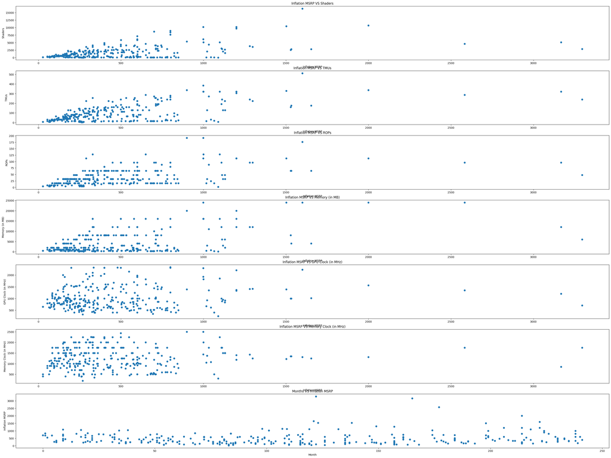

```python
# Creating 6 different graphs with Inflation MSRP on the X-axis
fig, axs = plt.subplots(7, 1, figsize=(40, 30))

axs[0].scatter(df['Inflation MSRP'], df['Shaders'])
axs[0].set_xlabel('Inflation MSRP')
axs[0].set_ylabel('Shaders')
axs[0].set_title('Inflation MSRP VS Shaders')

axs[1].scatter(df['Inflation MSRP'], df['TMUs'])
axs[1].set_xlabel('Inflation MSRP')
axs[1].set_ylabel('TMUs')
axs[1].set_title('Inflation MSRP VS TMUs')

axs[2].scatter(df['Inflation MSRP'], df['ROPs'])
axs[2].set_xlabel('Inflation MSRP')
axs[2].set_ylabel('ROPs')
axs[2].set_title('Inflation MSRP VS ROPs')

axs[3].scatter(df['Inflation MSRP'], df['Memory (in MB)'])
axs[3].set_xlabel('Inflation MSRP')
axs[3].set_ylabel('Memory (in MB)')
axs[3].set_title('Inflation MSRP VS Memory (in MB)')

axs[4].scatter(df['Inflation MSRP'], df['GPU Clock (in MHz)'])
axs[4].set_xlabel('Inflation MSRP')
axs[4].set_ylabel('GPU Clock (in MHz)')
axs[4].set_title('Inflation MSRP VS GPU Clock (in MHz)')

axs[5].scatter(df['Inflation MSRP'], df['Memory Clock (in MHz)'])
axs[5].set_xlabel('Inflation MSRP')
axs[5].set_ylabel('Memory Clock (in MHz)')
axs[5].set_title('Inflation MSRP VS Memory Clock (in MHz)')

axs[6].scatter(df['Month'], df['Inflation MSRP'])
axs[6].set_xlabel('Month')
axs[6].set_ylabel('Inflation MSRP')
axs[6].set_title('Months VS Inflation MSRP')
```

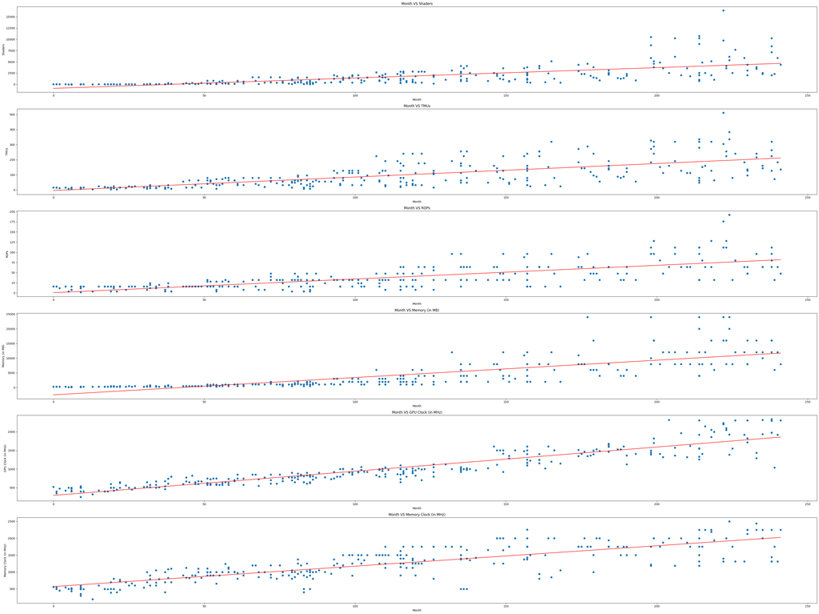

```python
# Creating 6 different graphs with Month on the X-axis
fig, axs = plt.subplots(6, 1, figsize=(40, 30))

scatter_variables = ['Shaders', 'TMUs', 'ROPs', 'Memory (in MB)', 'GPU Clock (in MHz)', 'Memory Clock (in MHz)']
for i, var in enumerate(scatter_variables):
    axs[i].scatter(df['Month'], df[var])
    axs[i].set_xlabel('Month')
    axs[i].set_ylabel(var)
    axs[i].set_title(f'Month VS {var}')

    # Line of best fit
    model = LinearRegression()
    model.fit(df[['Month']], df[var])
    axs[i].plot(df['Month'], model.predict(df[['Month']]), color='red')

plt.tight_layout()
plt.show()
```

We are going to create graphs that help us visualize the data in 3D, which will give us a better idea of the correlation when using months and prices as inputs.

```
/usr/local/lib/python3.10/dist-packages/sklearn/base.py:493: UserWarning: X does not have valid feature names, but LinearRegression was fitted with feature names
  warnings.warn(
/usr/local/lib/python3.10/dist-packages/sklearn/base.py:493: UserWarning: X does not have valid feature names, but LinearRegression was fitted with feature names
  warnings.warn(
```

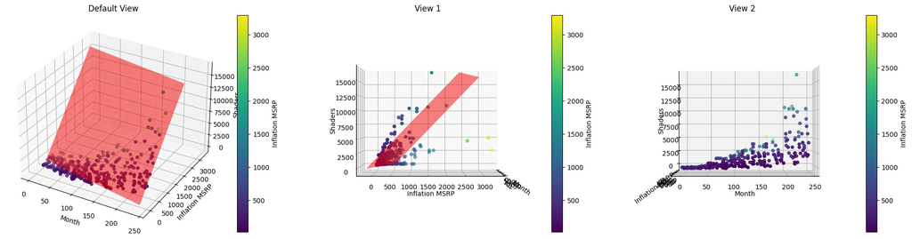

```python
%matplotlib inline

# Create a colormap
cmap = plt.cm.viridis

norm = plt.Normalize(df['Inflation MSRP'].min(), df['Inflation MSRP'].max())

fig = plt.figure(figsize=(20, 5))

ax1 = fig.add_subplot(131, projection='3d')
sc1 = ax1.scatter(df['Month'], df['Inflation MSRP'], df['Shaders'], c=df['Inflation MSRP'], cmap=cmap, marker='o', norm=norm)
ax1.set_title('Default View')
ax1.set_xlabel('Month')
ax1.set_ylabel('Inflation MSRP')
ax1.set_zlabel('Shaders')

# Fit line of best fit for default view
model1 = LinearRegression()
model1.fit(df[['Month', 'Shaders']], df['Inflation MSRP'])
mesh_x1, mesh_z1 = np.meshgrid(np.linspace(df['Month'].min(), df['Month'].max(), 10),
                                np.linspace(df['Shaders'].min(), df['Shaders'].max(), 10))
mesh_y1 = model1.predict(np.array([mesh_x1.flatten(), mesh_z1.flatten()]).T).reshape(mesh_x1.shape)
ax1.plot_surface(mesh_x1, mesh_y1, mesh_z1, alpha=0.5, color='r')

# View 1 (subplot 2)
ax2 = fig.add_subplot(132, projection='3d')
sc2 = ax2.scatter(df['Month'], df['Inflation MSRP'], df['Shaders'], c=df['Inflation MSRP'], cmap=cmap, marker='o', norm=norm)
ax2.set_title('View 1')
ax2.set_xlabel('Month')
ax2.set_ylabel('Inflation MSRP')
ax2.set_zlabel('Shaders')
ax2.view_init(elev=0, azim=0)  # Change view angle

# Fit line of best fit for view 1
model2 = LinearRegression()
model2.fit(df[['Month', 'Shaders']], df['Inflation MSRP'])
mesh_x2, mesh_z2 = np.meshgrid(np.linspace(df['Month'].min(), df['Month'].max(), 10),
                                np.linspace(df['Shaders'].min(), df['Shaders'].max(), 10))
mesh_y2 = model2.predict(np.array([mesh_x2.flatten(), mesh_z2.flatten()]).T).reshape(mesh_x2.shape)
ax2.plot_surface(mesh_x2, mesh_y2, mesh_z2, alpha=0.5, color='r')

# View 2 (subplot 3)
ax3 = fig.add_subplot(133, projection='3d')
sc3 = ax3.scatter(df['Month'], df['Inflation MSRP'], df['Shaders'], c=df['Inflation MSRP'], cmap=cmap, marker='o', norm=norm)
ax3.set_title('View 2')
ax3.set_xlabel('Month')
ax3.set_ylabel('Inflation MSRP')
ax3.set_zlabel('Shaders')
ax3.view_init(elev=0, azim=-90)  # Change view angle

# Add colorbars
cbar1 = fig.colorbar(sc1, ax=ax1)
cbar1.set_label('Inflation MSRP')

cbar2 = fig.colorbar(sc2, ax=ax2)
cbar2.set_label('Inflation MSRP')

cbar3 = fig.colorbar(sc3, ax=ax3)
cbar3.set_label('Inflation MSRP')

# Adjust layout
plt.tight_layout()

# Show plot
plt.show()
```

Inorge those warnings. Those warnings don't have any effect on the actual result.

```
/usr/local/lib/python3.10/dist-packages/sklearn/base.py:493: UserWarning: X does not have valid feature names, but LinearRegression was fitted with feature names
  warnings.warn(
/usr/local/lib/python3.10/dist-packages/sklearn/base.py:493: UserWarning: X does not have valid feature names, but LinearRegression was fitted with feature names
  warnings.warn(
```

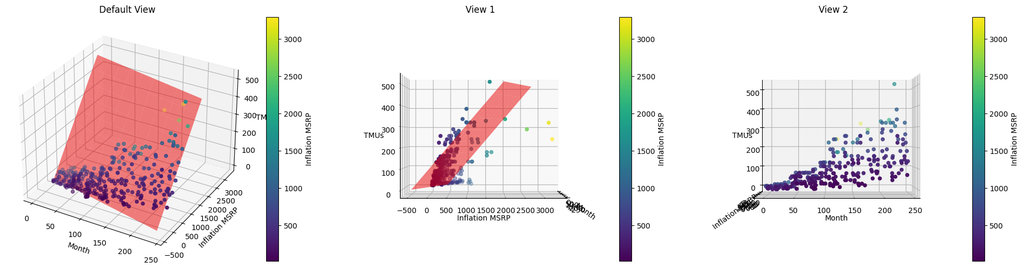

```python
%matplotlib inline

# Create a colormap
cmap = plt.cm.viridis

norm = plt.Normalize(df['Inflation MSRP'].min(), df['Inflation MSRP'].max())

fig = plt.figure(figsize=(20, 5))

ax1 = fig.add_subplot(131, projection='3d')
sc1 = ax1.scatter(df['Month'], df['Inflation MSRP'], df['TMUs'], c=df['Inflation MSRP'], cmap=cmap, marker='o', norm=norm)
ax1.set_title('Default View')
ax1.set_xlabel('Month')
ax1.set_ylabel('Inflation MSRP')
ax1.set_zlabel('TMUs')

# Fit line of best fit for default view
model1 = LinearRegression()
model1.fit(df[['Month', 'TMUs']], df['Inflation MSRP'])
mesh_x1, mesh_z1 = np.meshgrid(np.linspace(df['Month'].min(), df['Month'].max(), 10),
                                np.linspace(df['TMUs'].min(), df['TMUs'].max(), 10))
mesh_y1 = model1.predict(np.array([mesh_x1.flatten(), mesh_z1.flatten()]).T).reshape(mesh_x1.shape)
ax1.plot_surface(mesh_x1, mesh_y1, mesh_z1, alpha=0.5, color='r')

# View 1 (subplot 2)
ax2 = fig.add_subplot(132, projection='3d')
sc2 = ax2.scatter(df['Month'], df['Inflation MSRP'], df['TMUs'], c=df['Inflation MSRP'], cmap=cmap, marker='o', norm=norm)
ax2.set_title('View 1')
ax2.set_xlabel('Month')
ax2.set_ylabel('Inflation MSRP')
ax2.set_zlabel('TMUs')
ax2.view_init(elev=0, azim=0)  # Change view angle

# Fit line of best fit for view 1
model2 = LinearRegression()
model2.fit(df[['Month', 'TMUs']], df['Inflation MSRP'])
mesh_x2, mesh_z2 = np.meshgrid(np.linspace(df['Month'].min(), df['Month'].max(), 10),
                                np.linspace(df['TMUs'].min(), df['TMUs'].max(), 10))
mesh_y2 = model2.predict(np.array([mesh_x2.flatten(), mesh_z2.flatten()]).T).reshape(mesh_x2.shape)
ax2.plot_surface(mesh_x2, mesh_y2, mesh_z2, alpha=0.5, color='r')

# View 2 (subplot 3)
ax3 = fig.add_subplot(133, projection='3d')
sc3 = ax3.scatter(df['Month'], df['Inflation MSRP'], df['TMUs'], c=df['Inflation MSRP'], cmap=cmap, marker='o', norm=norm)
ax3.set_title('View 2')
ax3.set_xlabel('Month')
ax3.set_ylabel('Inflation MSRP')
ax3.set_zlabel('TMUs')
ax3.view_init(elev=0, azim=-90)  # Change view angle


# Add colorbars
cbar1 = fig.colorbar(sc1, ax=ax1)
cbar1.set_label('Inflation MSRP')

cbar2 = fig.colorbar(sc2, ax=ax2)
cbar2.set_label('Inflation MSRP')

cbar3 = fig.colorbar(sc3, ax=ax3)
cbar3.set_label('Inflation MSRP')

# Adjust layout
plt.tight_layout()

# Show plot
plt.show()
```

Inorge those warnings. Those warnings don't have any effect on the actual result.

```
/usr/local/lib/python3.10/dist-packages/sklearn/base.py:493: UserWarning: X does not have valid feature names, but LinearRegression was fitted with feature names
  warnings.warn(
/usr/local/lib/python3.10/dist-packages/sklearn/base.py:493: UserWarning: X does not have valid feature names, but LinearRegression was fitted with feature names
  warnings.warn(
```

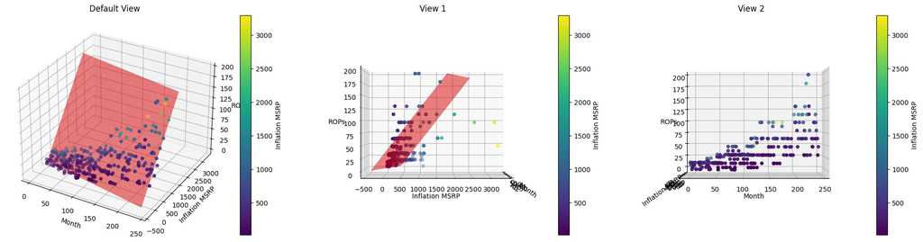

```python
%matplotlib inline

# Create a colormap
cmap = plt.cm.viridis

norm = plt.Normalize(df['Inflation MSRP'].min(), df['Inflation MSRP'].max())

fig = plt.figure(figsize=(20, 5))

ax1 = fig.add_subplot(131, projection='3d')
sc1 = ax1.scatter(df['Month'], df['Inflation MSRP'], df['ROPs'], c=df['Inflation MSRP'], cmap=cmap, marker='o', norm=norm)
ax1.set_title('Default View')
ax1.set_xlabel('Month')
ax1.set_ylabel('Inflation MSRP')
ax1.set_zlabel('ROPs')

# Fit line of best fit for default view
model1 = LinearRegression()
model1.fit(df[['Month', 'ROPs']], df['Inflation MSRP'])
mesh_x1, mesh_z1 = np.meshgrid(np.linspace(df['Month'].min(), df['Month'].max(), 10),
                                np.linspace(df['ROPs'].min(), df['ROPs'].max(), 10))
mesh_y1 = model1.predict(np.array([mesh_x1.flatten(), mesh_z1.flatten()]).T).reshape(mesh_x1.shape)
ax1.plot_surface(mesh_x1, mesh_y1, mesh_z1, alpha=0.5, color='r')

# View 1 (subplot 2)
ax2 = fig.add_subplot(132, projection='3d')
sc2 = ax2.scatter(df['Month'], df['Inflation MSRP'], df['ROPs'], c=df['Inflation MSRP'], cmap=cmap, marker='o', norm=norm)
ax2.set_title('View 1')
ax2.set_xlabel('Month')
ax2.set_ylabel('Inflation MSRP')
ax2.set_zlabel('ROPs')
ax2.view_init(elev=0, azim=0)  # Change view angle

# Fit line of best fit for view 1
model2 = LinearRegression()
model2.fit(df[['Month', 'ROPs']], df['Inflation MSRP'])
mesh_x2, mesh_z2 = np.meshgrid(np.linspace(df['Month'].min(), df['Month'].max(), 10),
                                np.linspace(df['ROPs'].min(), df['ROPs'].max(), 10))
mesh_y2 = model2.predict(np.array([mesh_x2.flatten(), mesh_z2.flatten()]).T).reshape(mesh_x2.shape)
ax2.plot_surface(mesh_x2, mesh_y2, mesh_z2, alpha=0.5, color='r')

# View 2 (subplot 3)
ax3 = fig.add_subplot(133, projection='3d')
sc3 = ax3.scatter(df['Month'], df['Inflation MSRP'], df['ROPs'], c=df['Inflation MSRP'], cmap=cmap, marker='o', norm=norm)
ax3.set_title('View 2')
ax3.set_xlabel('Month')
ax3.set_ylabel('Inflation MSRP')
ax3.set_zlabel('ROPs')
ax3.view_init(elev=0, azim=-90)  # Change view angle

# Add colorbars
cbar1 = fig.colorbar(sc1, ax=ax1)
cbar1.set_label('Inflation MSRP')

cbar2 = fig.colorbar(sc2, ax=ax2)
cbar2.set_label('Inflation MSRP')

cbar3 = fig.colorbar(sc3, ax=ax3)
cbar3.set_label('Inflation MSRP')

# Adjust layout
plt.tight_layout()

# Show plot
plt.show()
```

Inorge those warnings. Those warnings don't have any effect on the actual result.

```
/usr/local/lib/python3.10/dist-packages/sklearn/base.py:493: UserWarning: X does not have valid feature names, but LinearRegression was fitted with feature names
  warnings.warn(
/usr/local/lib/python3.10/dist-packages/sklearn/base.py:493: UserWarning: X does not have valid feature names, but LinearRegression was fitted with feature names
  warnings.warn(
```

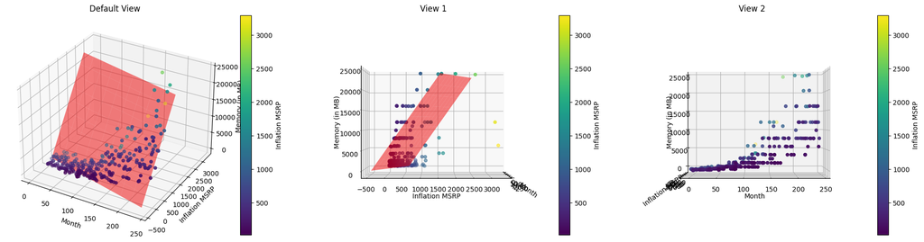

```python
%matplotlib inline

# Create a colormap
cmap = plt.cm.viridis

norm = plt.Normalize(df['Inflation MSRP'].min(), df['Inflation MSRP'].max())

fig = plt.figure(figsize=(20, 5))

ax1 = fig.add_subplot(131, projection='3d')
sc1 = ax1.scatter(df['Month'], df['Inflation MSRP'], df['Memory (in MB)'], c=df['Inflation MSRP'], cmap=cmap, marker='o', norm=norm)
ax1.set_title('Default View')
ax1.set_xlabel('Month')
ax1.set_ylabel('Inflation MSRP')
ax1.set_zlabel('Memory (in MB)')

# Fit line of best fit for default view
model1 = LinearRegression()
model1.fit(df[['Month', 'Memory (in MB)']], df['Inflation MSRP'])
mesh_x1, mesh_z1 = np.meshgrid(np.linspace(df['Month'].min(), df['Month'].max(), 10),
                                np.linspace(df['Memory (in MB)'].min(), df['Memory (in MB)'].max(), 10))
mesh_y1 = model1.predict(np.array([mesh_x1.flatten(), mesh_z1.flatten()]).T).reshape(mesh_x1.shape)
ax1.plot_surface(mesh_x1, mesh_y1, mesh_z1, alpha=0.5, color='r')

# View 1 (subplot 2)
ax2 = fig.add_subplot(132, projection='3d')
sc2 = ax2.scatter(df['Month'], df['Inflation MSRP'], df['Memory (in MB)'], c=df['Inflation MSRP'], cmap=cmap, marker='o', norm=norm)
ax2.set_title('View 1')
ax2.set_xlabel('Month')
ax2.set_ylabel('Inflation MSRP')
ax2.set_zlabel('Memory (in MB)')
ax2.view_init(elev=0, azim=0)  # Change view angle

# Fit line of best fit for view 1
model2 = LinearRegression()
model2.fit(df[['Month', 'Memory (in MB)']], df['Inflation MSRP'])
mesh_x2, mesh_z2 = np.meshgrid(np.linspace(df['Month'].min(), df['Month'].max(), 10),
                                np.linspace(df['Memory (in MB)'].min(), df['Memory (in MB)'].max(), 10))
mesh_y2 = model2.predict(np.array([mesh_x2.flatten(), mesh_z2.flatten()]).T).reshape(mesh_x2.shape)
ax2.plot_surface(mesh_x2, mesh_y2, mesh_z2, alpha=0.5, color='r')

# View 2 (subplot 3)
ax3 = fig.add_subplot(133, projection='3d')
sc3 = ax3.scatter(df['Month'], df['Inflation MSRP'], df['Memory (in MB)'], c=df['Inflation MSRP'], cmap=cmap, marker='o', norm=norm)
ax3.set_title('View 2')
ax3.set_xlabel('Month')
ax3.set_ylabel('Inflation MSRP')
ax3.set_zlabel('Memory (in MB)')
ax3.view_init(elev=0, azim=-90)  # Change view angle

# Add colorbars
cbar1 = fig.colorbar(sc1, ax=ax1)
cbar1.set_label('Inflation MSRP')

cbar2 = fig.colorbar(sc2, ax=ax2)
cbar2.set_label('Inflation MSRP')

cbar3 = fig.colorbar(sc3, ax=ax3)
cbar3.set_label('Inflation MSRP')

# Adjust layout
plt.tight_layout()

# Show plot
plt.show()
```

Inorge those warnings. Those warnings don't have any effect on the actual result.

```
/usr/local/lib/python3.10/dist-packages/sklearn/base.py:493: UserWarning: X does not have valid feature names, but LinearRegression was fitted with feature names
  warnings.warn(
/usr/local/lib/python3.10/dist-packages/sklearn/base.py:493: UserWarning: X does not have valid feature names, but LinearRegression was fitted with feature names
  warnings.warn(
```

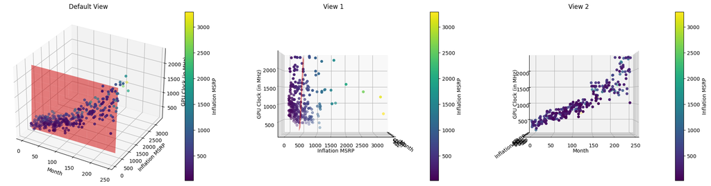

```python
%matplotlib inline

# Create a colormap
cmap = plt.cm.viridis

norm = plt.Normalize(df['Inflation MSRP'].min(), df['Inflation MSRP'].max())

fig = plt.figure(figsize=(20, 5))

ax1 = fig.add_subplot(131, projection='3d')
sc1 = ax1.scatter(df['Month'], df['Inflation MSRP'], df['GPU Clock (in MHz)'], c=df['Inflation MSRP'], cmap=cmap, marker='o', norm=norm)
ax1.set_title('Default View')
ax1.set_xlabel('Month')
ax1.set_ylabel('Inflation MSRP')
ax1.set_zlabel('GPU Clock (in MHz)')

# Fit line of best fit for default view
model1 = LinearRegression()
model1.fit(df[['Month', 'GPU Clock (in MHz)']], df['Inflation MSRP'])
mesh_x1, mesh_z1 = np.meshgrid(np.linspace(df['Month'].min(), df['Month'].max(), 10),
                                np.linspace(df['GPU Clock (in MHz)'].min(), df['GPU Clock (in MHz)'].max(), 10))
mesh_y1 = model1.predict(np.array([mesh_x1.flatten(), mesh_z1.flatten()]).T).reshape(mesh_x1.shape)
ax1.plot_surface(mesh_x1, mesh_y1, mesh_z1, alpha=0.5, color='r')

# View 1 (subplot 2)
ax2 = fig.add_subplot(132, projection='3d')
sc2 = ax2.scatter(df['Month'], df['Inflation MSRP'], df['GPU Clock (in MHz)'], c=df['Inflation MSRP'], cmap=cmap, marker='o', norm=norm)
ax2.set_title('View 1')
ax2.set_xlabel('Month')
ax2.set_ylabel('Inflation MSRP')
ax2.set_zlabel('GPU Clock (in MHz)')
ax2.view_init(elev=0, azim=0)  # Change view angle

# Fit line of best fit for view 1
model2 = LinearRegression()
model2.fit(df[['Month', 'GPU Clock (in MHz)']], df['Inflation MSRP'])
mesh_x2, mesh_z2 = np.meshgrid(np.linspace(df['Month'].min(), df['Month'].max(), 10),
                                np.linspace(df['GPU Clock (in MHz)'].min(), df['GPU Clock (in MHz)'].max(), 10))
mesh_y2 = model2.predict(np.array([mesh_x2.flatten(), mesh_z2.flatten()]).T).reshape(mesh_x2.shape)
ax2.plot_surface(mesh_x2, mesh_y2, mesh_z2, alpha=0.5, color='r')


# View 2 (subplot 3)
ax3 = fig.add_subplot(133, projection='3d')
sc3 = ax3.scatter(df['Month'], df['Inflation MSRP'], df['GPU Clock (in MHz)'], c=df['Inflation MSRP'], cmap=cmap, marker='o', norm=norm)
ax3.set_title('View 2')
ax3.set_xlabel('Month')
ax3.set_ylabel('Inflation MSRP')
ax3.set_zlabel('GPU Clock (in MHz)')
ax3.view_init(elev=0, azim=-90)  # Change view angle

# Add colorbars
cbar1 = fig.colorbar(sc1, ax=ax1)
cbar1.set_label('Inflation MSRP')

cbar2 = fig.colorbar(sc2, ax=ax2)
cbar2.set_label('Inflation MSRP')

cbar3 = fig.colorbar(sc3, ax=ax3)
cbar3.set_label('Inflation MSRP')

# Adjust layout
plt.tight_layout()

# Show plot
plt.show()
```

Inorge those warnings. Those warnings don't have any effect on the actual result.

```
/usr/local/lib/python3.10/dist-packages/sklearn/base.py:493: UserWarning: X does not have valid feature names, but LinearRegression was fitted with feature names
  warnings.warn(
/usr/local/lib/python3.10/dist-packages/sklearn/base.py:493: UserWarning: X does not have valid feature names, but LinearRegression was fitted with feature names
  warnings.warn(
```

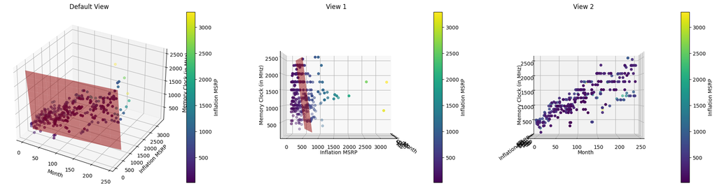

```python
%matplotlib inline

# Create a colormap
cmap = plt.cm.viridis

norm = plt.Normalize(df['Inflation MSRP'].min(), df['Inflation MSRP'].max())

fig = plt.figure(figsize=(20, 5))

ax1 = fig.add_subplot(131, projection='3d')
sc1 = ax1.scatter(df['Month'], df['Inflation MSRP'], df['Memory Clock (in MHz)'], c=df['Inflation MSRP'], cmap=cmap, marker='o', norm=norm)
ax1.set_title('Default View')
ax1.set_xlabel('Month')
ax1.set_ylabel('Inflation MSRP')
ax1.set_zlabel('Memory Clock (in MHz)')

# Fit line of best fit for default view
model1 = LinearRegression()
model1.fit(df[['Month', 'Memory Clock (in MHz)']], df['Inflation MSRP'])
mesh_x1, mesh_z1 = np.meshgrid(np.linspace(df['Month'].min(), df['Month'].max(), 10),
                                np.linspace(df['Memory Clock (in MHz)'].min(), df['Memory Clock (in MHz)'].max(), 10))
mesh_y1 = model1.predict(np.array([mesh_x1.flatten(), mesh_z1.flatten()]).T).reshape(mesh_x1.shape)
ax1.plot_surface(mesh_x1, mesh_y1, mesh_z1, alpha=0.5, color='r')

# View 1 (subplot 2)
ax2 = fig.add_subplot(132, projection='3d')
sc2 = ax2.scatter(df['Month'], df['Inflation MSRP'], df['Memory Clock (in MHz)'], c=df['Inflation MSRP'], cmap=cmap, marker='o', norm=norm)
ax2.set_title('View 1')
ax2.set_xlabel('Month')
ax2.set_ylabel('Inflation MSRP')
ax2.set_zlabel('Memory Clock (in MHz)')
ax2.view_init(elev=0, azim=0)  # Change view angle

# Fit line of best fit for view 1
model2 = LinearRegression()
model2.fit(df[['Month', 'Memory Clock (in MHz)']], df['Inflation MSRP'])
mesh_x2, mesh_z2 = np.meshgrid(np.linspace(df['Month'].min(), df['Month'].max(), 10),
                                np.linspace(df['Memory Clock (in MHz)'].min(), df['Memory Clock (in MHz)'].max(), 10))
mesh_y2 = model2.predict(np.array([mesh_x2.flatten(), mesh_z2.flatten()]).T).reshape(mesh_x2.shape)
ax2.plot_surface(mesh_x2, mesh_y2, mesh_z2, alpha=0.5, color='r')

# View 2 (subplot 3)
ax3 = fig.add_subplot(133, projection='3d')
sc3 = ax3.scatter(df['Month'], df['Inflation MSRP'], df['Memory Clock (in MHz)'], c=df['Inflation MSRP'], cmap=cmap, marker='o', norm=norm)
ax3.set_title('View 2')
ax3.set_xlabel('Month')
ax3.set_ylabel('Inflation MSRP')
ax3.set_zlabel('Memory Clock (in MHz)')
ax3.view_init(elev=0, azim=-90)  # Change view angle

# Add colorbars
cbar1 = fig.colorbar(sc1, ax=ax1)
cbar1.set_label('Inflation MSRP')

cbar2 = fig.colorbar(sc2, ax=ax2)
cbar2.set_label('Inflation MSRP')

cbar3 = fig.colorbar(sc3, ax=ax3)
cbar3.set_label('Inflation MSRP')

# Adjust layout
plt.tight_layout()

# Show plot
plt.show()
```

Inorge those warnings. Those warnings don't have any effect on the actual result.

After examining all the graphs, we believe a regression linear model will best fit this particular data set.

### Model: Analysis, Hypothesis Testing, Machine Learning

We will randomly pick the training and test data with a ratio of 8:2

```python
#shuffling dataframe
shuffled_df = df.sample(frac=1, random_state=42)

#removing unneeded columns
shuffled_df = shuffled_df.drop(columns=['Released Date', 'Product Name', 'Memory (in MB)'])

# Split the shuffled DataFrame into training and testing sets
train_ratio = 0.8  # Ratio of training data, adjust as needed
train_size = int(train_ratio * len(shuffled_df))

train_df = shuffled_df[:train_size]  # Training data
test_df = shuffled_df[train_size:]   # Testing data

# Optionally, you can reset the index of the DataFrames
train_df.reset_index(drop=True, inplace=True)
test_df.reset_index(drop=True, inplace=True)
```

```python
test_df.head(10)
```

|  | Inflation MSRP | Month | Shaders | TMUs | ROPs | GPU Clock (in MHz) | Memory Clock (in MHz) |
| --- | --- | --- | --- | --- | --- | --- | --- |
| 0 | 173.54 | 137 | 768 | 48 | 32 | 1024 | 1653 |
| 1 | 680.51 | 9 | 22 | 16 | 16 | 500 | 500 |
| 2 | 252.42 | 37 | 32 | 16 | 8 | 675 | 1000 |
| 3 | 575.65 | 72 | 1600 | 80 | 32 | 850 | 1200 |
| 4 | 329.00 | 211 | 1792 | 112 | 64 | 1626 | 1750 |
| 5 | 743.80 | 161 | 4096 | 256 | 64 | 1406 | 945 |
| 6 | 399.00 | 218 | 2048 | 128 | 64 | 2055 | 2190 |
| 7 | 708.34 | 137 | 4096 | 256 | 64 | 1000 | 500 |
| 8 | 722.81 | 114 | 2304 | 192 | 48 | 863 | 1502 |
| 9 | 1017.11 | 34 | 56 | 16 | 16 | 670 | 1050 |

```python
train_df.head(10)
```

|  | Inflation MSRP | Month | Shaders | TMUs | ROPs | GPU Clock (in MHz) | Memory Clock (in MHz) |
| --- | --- | --- | --- | --- | --- | --- | --- |
| 0 | 3295.04 | 122 | 2880 | 240 | 48 | 705 | 1750 |
| 1 | 670.28 | 109 | 1536 | 128 | 32 | 1006 | 1502 |
| 2 | 355.94 | 81 | 1408 | 88 | 32 | 800 | 1250 |
| 3 | 250.79 | 140 | 2048 | 128 | 32 | 970 | 1425 |
| 4 | 220.89 | 47 | 64 | 32 | 16 | 600 | 700 |
| 5 | 246.04 | 6 | 22 | 16 | 16 | 500 | 500 |
| 6 | 822.70 | 84 | 512 | 64 | 48 | 608 | 854 |
| 7 | 726.99 | 110 | 2304 | 192 | 48 | 863 | 1502 |
| 8 | 332.62 | 115 | 2048 | 128 | 32 | 850 | 1500 |
| 9 | 780.90 | 25 | 32 | 24 | 16 | 500 | 600 |

```python
# Training data (X, y), T time steps, alpha step
def grad_descent(X, y, T, alpha):
    m, n = X.shape              # m = #examples, n = #features
    theta = np.zeros((n, 1))    # initialize parameters
    f = np.zeros(T)             # track loss over time

    for i in range(T):
        # loss for current parameter vector theta
        f[i] = 0.5* np.linalg.norm(X.dot(theta) - y)**2
        # compute steepest ascent at f(theta)
        g = np.transpose(X).dot(X.dot(theta) - y)
        # step down the gradient
        theta = theta - alpha * g
    return theta, f
```

```python
#data to train model for shaders
arr_shade = train_df.to_numpy()

# delete all columns except release MSRP and Month to get the indipendant variables
X_shade = arr_shade[:, [0, 1]]
# Add a column of ones (bias term) to the feature matrix X
X_shade = np.hstack((np.ones((X_shade.shape[0], 1)), X_shade))

# Transforming features to represent an exponential relationship
X_shade[:, 0] = np.log(X_shade[:, 0])  # Take the natural logarithm of MSRP
X_shade[:, 1] = np.log(X_shade[:, 1])  # Take the natural logarithm of Month

# only keep the dependant data (number of shader cores)
y_shade = arr_shade[:, [2]]

T = 10000
alpha = 0.000000001
theta, loss = grad_descent(X_shade,y_shade,T,alpha)
weights_shade = theta[1:]
print("Weights:")
print("MSRP:", weights_shade[0])
print("Month:", weights_shade[1])
```

```
Weights:
MSRP: [-0.7427768]
Month: [17.70176675]
```

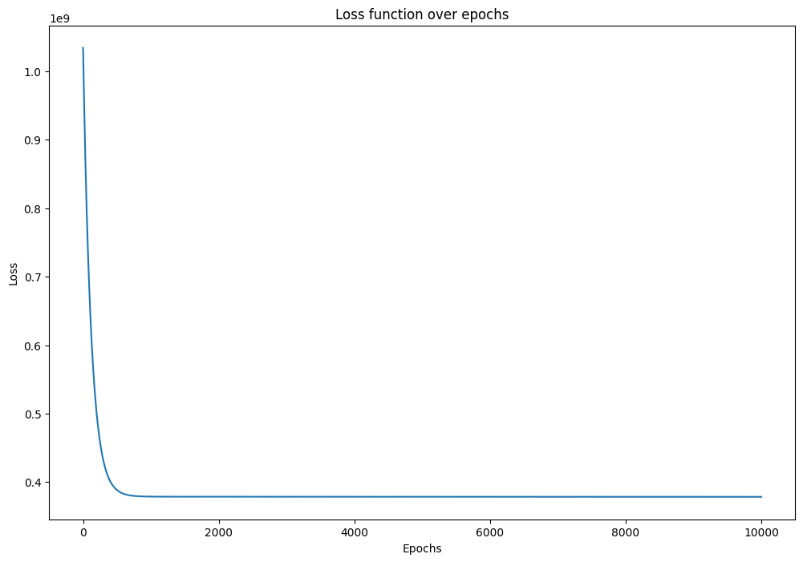

```python
plt.figure(figsize=(12, 8))
plt.plot(range(T), loss)
plt.xlabel('Epochs')
plt.ylabel('Loss')
plt.title('Loss function over epochs')
plt.show()
```

```python
X_test = test_df[['Inflation MSRP', 'Month']].values
y_test = test_df['Shaders'].values.reshape(-1, 1)

# Add a column of ones for bias term
X_test = np.c_[np.ones((len(X_test), 1)), X_test]

# Use the learned weights to make predictions
predictions = X_test.dot(theta)

# Store the actual vs prediction data in a dataframe
result_df = test_df[["Shaders"]].copy()
result_df.rename(columns={'Shaders': 'Actual Shaders'}, inplace=True)
result_df['Predicted Shaders'] = np.nan

for i in range(len(predictions)):
    result_df.loc[i, "Predicted Shaders"] = predictions[i][0]

result_df.head(10)
```

|  | Actual Shaders | Predicted Shaders |
| --- | --- | --- |
| 0 | 768 | 2296.240560 |
| 1 | 22 | -346.151137 |
| 2 | 32 | 467.473651 |
| 3 | 1600 | 846.947743 |
| 4 | 1792 | 3490.699218 |
| 5 | 4096 | 2297.507066 |
| 6 | 2048 | 3562.617210 |
| 7 | 4096 | 1899.003529 |
| 8 | 2304 | 1481.114913 |
| 9 | 56 | -153.625638 |

```python
# Step 1: Compute absolute differences
absolute_diff = np.abs(predictions - y_test)

# Step 2: Compute Mean Absolute Error (MAE)
mae = np.mean(absolute_diff)

# Step 3: Compute the standard deviation of the observed data
std_dev = np.std(y_test)

# Step 4: Calculate the average number of standard deviations away
average_std_devs_away = mae / std_dev

print("Mean Absolute Error (MAE):", mae)
print("Standard Deviation of Observed Data:", std_dev)
print("Average Number of Standard Deviations Away:", average_std_devs_away)
```

```
Mean Absolute Error (MAE): 956.4060638138263
Standard Deviation of Observed Data: 1745.9084812262922
Average Number of Standard Deviations Away: 0.5477985095427598
```

```python
#data to train model for TPUs
arr_tmu = train_df.to_numpy()

# delete all columns except release MSRP and Month to get the indipendant variables
X_tmu = arr_tmu[:, [0, 1]]
# Add a column of ones (bias term) to the feature matrix X
X_tmu = np.hstack((np.ones((X_tmu.shape[0], 1)), X_tmu))

# only keep the dependant data (number of TPU cores)
y_tmu = arr_tmu[:, [3]]

T = 1000
alpha = 0.00000001
theta, loss = grad_descent(X_tmu,y_tmu,T,alpha)
weights_tmu = theta[1:]
print("Weights:")
print("MSRP:", weights_tmu[0])
print("Month:", weights_tmu[1])
```

```
Weights:
MSRP: [0.08607969]
Month: [0.60968142]
```

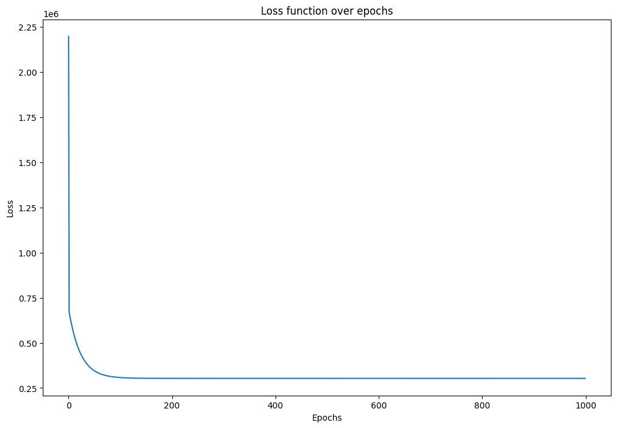

```python
plt.figure(figsize=(12, 8))
plt.plot(range(T), loss)
plt.xlabel('Epochs')
plt.ylabel('Loss')
plt.title('Loss function over epochs')
plt.show()
```

```python
X_test = test_df[['Inflation MSRP', 'Month']].values
y_test = test_df['TMUs'].values.reshape(-1, 1)

# Add a column of ones for bias term
X_test = np.c_[np.ones((len(X_test), 1)), X_test]

# Use the learned weights to make predictions
predictions = X_test.dot(theta)

# Clear the old data inside of the dataframe
result_df.drop(result_df.index, inplace=True)

# Store the actual vs prediction data in a dataframe
result_df = test_df[["TMUs"]].copy()
result_df.rename(columns={'TMUs': 'Actual TMUs'}, inplace=True)
result_df['Predicted TMUs'] = np.nan

for i in range(len(predictions)):
    result_df.loc[i, "Predicted TMUs"] = predictions[i][0]

result_df.head(10)
```

|  | Actual TMUs | Predicted TMUs |
| --- | --- | --- |
| 0 | 48 | 98.442338 |
| 1 | 16 | 64.042938 |
| 2 | 16 | 44.264162 |
| 3 | 80 | 93.426551 |
| 4 | 112 | 156.940712 |
| 5 | 256 | 162.162498 |
| 6 | 128 | 167.234061 |
| 7 | 256 | 144.477758 |
| 8 | 192 | 131.700658 |
| 9 | 16 | 108.259398 |

```python
# Step 1: Compute absolute differences
absolute_diff = np.abs(predictions - y_test)

# Step 2: Compute Mean Absolute Error (MAE)
mae = np.mean(absolute_diff)

# Step 3: Compute the standard deviation of the observed data
std_dev = np.std(y_test)

# Step 4: Calculate the average number of standard deviations away
average_std_devs_away = mae / std_dev

print("Mean Absolute Error (MAE):", mae)
print("Standard Deviation of Observed Data:", std_dev)
print("Average Number of Standard Deviations Away:", average_std_devs_away)
```

```
Mean Absolute Error (MAE): 37.51290079863598
Standard Deviation of Observed Data: 69.57232217259241
Average Number of Standard Deviations Away: 0.5391928805477469
```

```python
#data to train model for ROPs
arr_rop = train_df.to_numpy()

# delete all columns except release MSRP and Month to get the indipendant variables
X_rop = arr_rop[:, [0, 1]]
# Add a column of ones (bias term) to the feature matrix X
X_rop = np.hstack((np.ones((X_rop.shape[0], 1)), X_rop))

# only keep the dependant data (number of ROP cores)
y_rop = arr_rop[:, [4]]

T = 1000
alpha = 0.00000001
theta, loss = grad_descent(X_rop,y_rop,T,alpha)
weights_rop = theta[1:]
print("Weights:")
print("MSRP:", weights_rop[0])
print("Month:", weights_rop[1])
```

```
Weights:
MSRP: [0.0260356]
Month: [0.26319834]
```

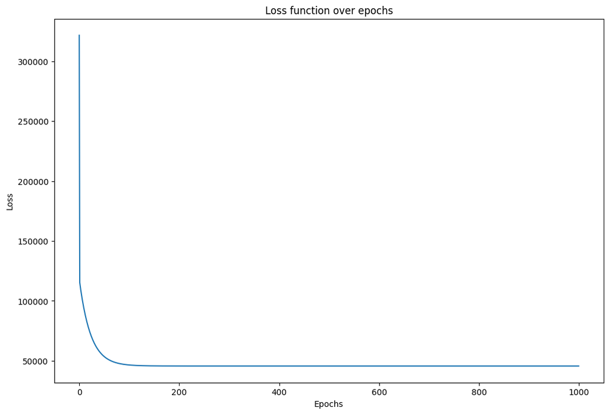

```python
plt.figure(figsize=(12, 8))
plt.plot(range(T), loss)
plt.xlabel('Epochs')
plt.ylabel('Loss')
plt.title('Loss function over epochs')
plt.show()
```

The **[loss function](https://www.datacamp.com/tutorial/loss-function-in-machine-learning)**, also known as the error function, quantifies the prediction accuracy. Those loss function graphs will help us visualize the model better and tune the **[learning rate and step size](https://machinelearningmastery.com/understand-the-dynamics-of-learning-rate-on-deep-learning-neural-networks/)** to improve the model further.

```python
X_test = test_df[['Inflation MSRP', 'Month']].values
y_test = test_df['ROPs'].values.reshape(-1, 1)

# Add a column of ones for bias term
X_test = np.c_[np.ones((len(X_test), 1)), X_test]

# Use the learned weights to make predictions
predictions = X_test.dot(theta)

# Clear the old data inside of the dataframe
result_df.drop(result_df.index, inplace=True)

# Store the actual vs prediction data in a dataframe
result_df = test_df[["ROPs"]].copy()
result_df.rename(columns={'ROPs': 'Actual ROPs'}, inplace=True)
result_df['Predicted ROPs'] = np.nan

for i in range(len(predictions)):
    result_df.loc[i, "Predicted ROPs"] = predictions[i][0]

result_df.head(10)
```

|  | Actual ROPs | Predicted ROPs |
| --- | --- | --- |
| 0 | 32 | 40.570722 |
| 1 | 16 | 20.080600 |
| 2 | 8 | 16.304576 |
| 3 | 32 | 33.932003 |
| 4 | 64 | 64.094893 |
| 5 | 64 | 61.734541 |
| 6 | 64 | 67.759773 |
| 7 | 64 | 54.494559 |
| 8 | 48 | 48.817732 |
| 9 | 16 | 35.424141 |

```python
# Step 1: Compute absolute differences
absolute_diff = np.abs(predictions - y_test)

# Step 2: Compute Mean Absolute Error (MAE)
mae = np.mean(absolute_diff)

# Step 3: Compute the standard deviation of the observed data
std_dev = np.std(y_test)

# Step 4: Calculate the average number of standard deviations away
average_std_devs_away = mae / std_dev

print("Mean Absolute Error (MAE):", mae)
print("Standard Deviation of Observed Data:", std_dev)
print("Average Number of Standard Deviations Away:", average_std_devs_away)
```

```
Mean Absolute Error (MAE): 11.839551004450046
Standard Deviation of Observed Data: 24.714393553135626
Average Number of Standard Deviations Away: 0.47905488674019714
```

```python
#data to train model for GPU clock speed
arr_clock = train_df.to_numpy()

# delete all columns except release MSRP and Month to get the indipendant variables
X_clock = arr_clock[:, [0, 1]]
# Add a column of ones (bias term) to the feature matrix X
X_clock = np.hstack((np.ones((X_clock.shape[0], 1)), X_clock))

# only keep the dependant data (number of ROP cores)
y_clock = arr_clock[:, [5]]

T = 5000
alpha = 0.000000001
theta, loss = grad_descent(X_clock,y_clock,T,alpha)
weights_clock = theta[1:]
print("Weights:")
print("MSRP:", weights_clock[0])
print("Month:", weights_clock[1])
```

```
Weights:
MSRP: [0.13707193]
Month: [7.88099185]
```

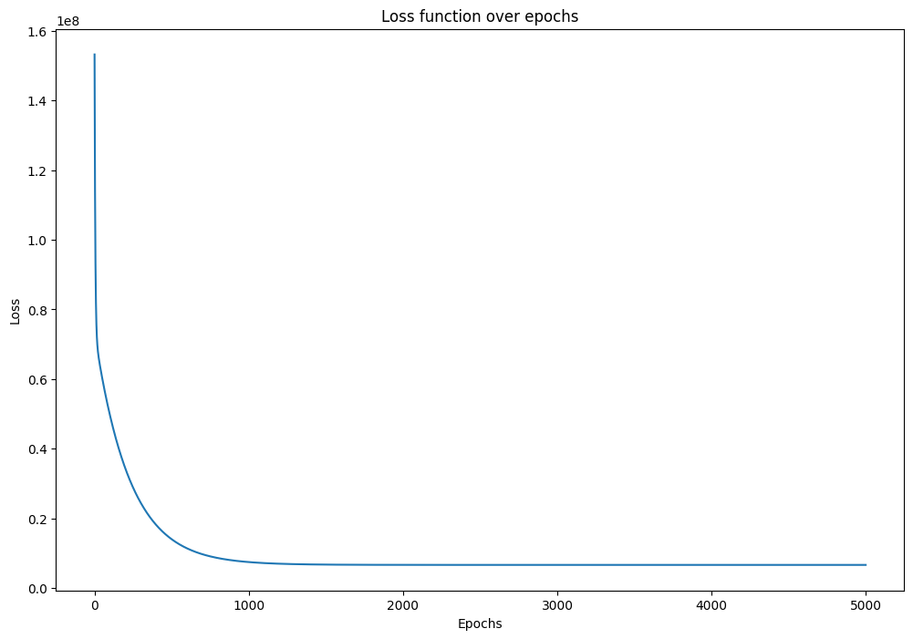

```python
plt.figure(figsize=(12, 8))
plt.plot(range(T), loss)
plt.xlabel('Epochs')
plt.ylabel('Loss')
plt.title('Loss function over epochs')
plt.show()
```

```python
X_test = test_df[['Inflation MSRP', 'Month']].values
y_test = test_df['GPU Clock (in MHz)'].values.reshape(-1, 1)

# Add a column of ones for bias term
X_test = np.c_[np.ones((len(X_test), 1)), X_test]

# Use the learned weights to make predictions
predictions = X_test.dot(theta)

# Clear the old data inside of the dataframe
result_df.drop(result_df.index, inplace=True)

# Store the actual vs prediction data in a dataframe
result_df = test_df[["GPU Clock (in MHz)"]].copy()
result_df.rename(columns={'GPU Clock (in MHz)': 'Actual GPU Clock (in MHz)'}, inplace=True)
result_df['Predicted GPU Clock (in MHz)'] = np.nan

for i in range(len(predictions)):
    result_df.loc[i, "Predicted GPU Clock (in MHz)"] = predictions[i][0]

result_df.head(10)
```

|  | Actual GPU Clock (in MHz) | Predicted GPU Clock (in MHz) |
| --- | --- | --- |
| 0 | 1024 | 1103.605535 |
| 1 | 500 | 164.329935 |
| 2 | 675 | 326.318584 |
| 3 | 850 | 646.459059 |
| 4 | 1626 | 1708.108134 |
| 5 | 1406 | 1370.915978 |
| 6 | 2055 | 1772.870112 |
| 7 | 1000 | 1176.911603 |
| 8 | 863 | 997.632221 |
| 9 | 670 | 407.493143 |

```python
# Step 1: Compute absolute differences
absolute_diff = np.abs(predictions - y_test)

# Step 2: Compute Mean Absolute Error (MAE)
mae = np.mean(absolute_diff)

# Step 3: Compute the standard deviation of the observed data
std_dev = np.std(y_test)

# Step 4: Calculate the average number of standard deviations away
average_std_devs_away = mae / std_dev

print("Mean Absolute Error (MAE):", mae)
print("Standard Deviation of Observed Data:", std_dev)
print("Average Number of Standard Deviations Away:", average_std_devs_away)
```

```
Mean Absolute Error (MAE): 174.85209731723015
Standard Deviation of Observed Data: 514.8340750862623
Average Number of Standard Deviations Away: 0.3396280583951889
```

```python
#data to train model for memory speed
arr_mspeed = train_df.to_numpy()

# delete all columns except release MSRP and Month to get the indipendant variables
X_mspeed = arr_mspeed[:, [0, 1]]
# Add a column of ones (bias term) to the feature matrix X
X_mspeed = np.hstack((np.ones((X_mspeed.shape[0], 1)), X_mspeed))

# only keep the dependant data (number of ROP cores)
y_mspeed = arr_mspeed[:, [6]]

T = 1000
alpha = 0.00000001
theta, loss = grad_descent(X_mspeed,y_mspeed,T,alpha)
weights_mspeed = theta[1:]
print("Weights:")
print("MSRP:", weights_mspeed[0])
print("Month:", weights_mspeed[1])
```

```
Weights:
MSRP: [0.17177504]
Month: [9.19702747]
```

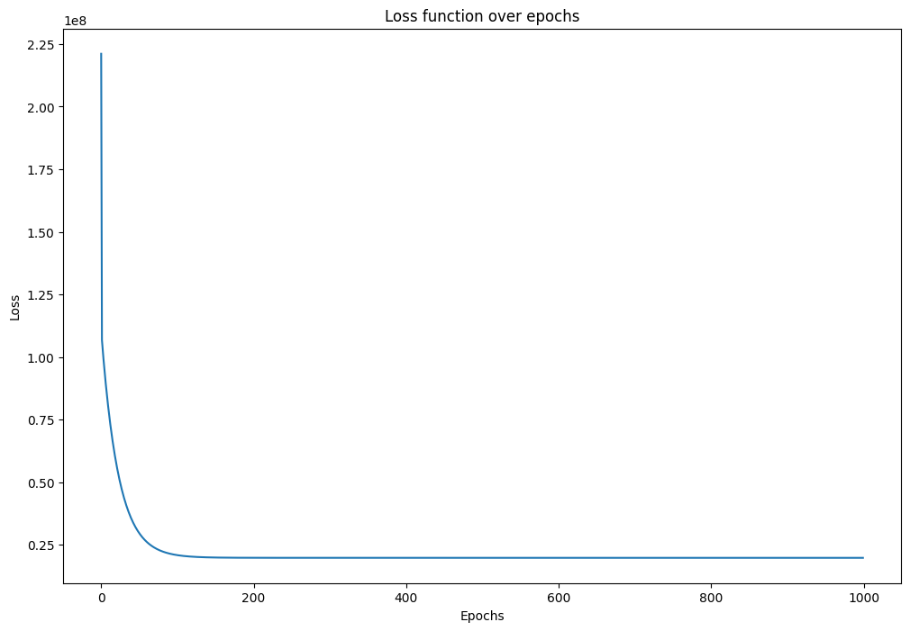

```python
plt.figure(figsize=(12, 8))
plt.plot(range(T), loss)
plt.xlabel('Epochs')
plt.ylabel('Loss')
plt.title('Loss function over epochs')
plt.show()
```

```python
X_test = test_df[['Inflation MSRP', 'Month']].values
y_test = test_df['Memory Clock (in MHz)'].values.reshape(-1, 1)

# Add a column of ones for bias term
X_test = np.c_[np.ones((len(X_test), 1)), X_test]

# Use the learned weights to make predictions
predictions = X_test.dot(theta)

# Clear the old data inside of the dataframe
result_df.drop(result_df.index, inplace=True)

# Store the actual vs prediction data in a dataframe
result_df = test_df[["Memory Clock (in MHz)"]].copy()
result_df.rename(columns={'Memory Clock (in MHz)': 'Actual Memory Clock (in MHz)'}, inplace=True)
result_df['Predicted Memory Clock (in MHz)'] = np.nan

for i in range(len(predictions)):
    result_df.loc[i, "Predicted Memory Clock (in MHz)"] = predictions[i][0]

result_df.head(10)
```

|  | Actual Memory Clock (in MHz) | Predicted Memory Clock (in MHz) |
| --- | --- | --- |
| 0 | 1653 | 1290.173655 |
| 1 | 500 | 200.038932 |
| 2 | 1000 | 384.020524 |
| 3 | 1200 | 761.439332 |
| 4 | 1750 | 1997.457836 |
| 5 | 945 | 1608.858750 |
| 6 | 2190 | 2073.861281 |
| 7 | 500 | 1382.038947 |
| 8 | 1502 | 1172.992901 |
| 9 | 1050 | 487.784098 |

```python
# Step 1: Compute absolute differences
absolute_diff = np.abs(predictions - y_test)

# Step 2: Compute Mean Absolute Error (MAE)
mae = np.mean(absolute_diff)

# Step 3: Compute the standard deviation of the observed data
std_dev = np.std(y_test)

# Step 4: Calculate the average number of standard deviations away
average_std_devs_away = mae / std_dev

print("Mean Absolute Error (MAE):", mae)
print("Standard Deviation of Observed Data:", std_dev)
print("Average Number of Standard Deviations Away:", average_std_devs_away)
```

```
Mean Absolute Error (MAE): 326.76134844247116
Standard Deviation of Observed Data: 496.5459069100205
Average Number of Standard Deviations Away: 0.6580687583870948
```

```python
# Get random 5 test GPUs from the test data set
sub_test_df = test_df.sample(n=5)
sub_test_df.reset_index(drop=True, inplace=True)

# Create five new coulmns to store the predicted data
sub_test_df['Predicted Shaders'], sub_test_df['Predicted TMUs'], sub_test_df['Predicted ROPs'], sub_test_df['Predicted GPU Clock (in MHz)'], sub_test_df['Predicted Memory Clock (in MHz)'] = [np.nan, np.nan, np.nan, np.nan, np.nan]

# Change the order and the names of the columns for readability
new_order = ['Inflation MSRP', 'Month', 'Shaders', 'Predicted Shaders', 'TMUs', 'Predicted TMUs', 'ROPs', 'Predicted ROPs', 'GPU Clock (in MHz)', 'Predicted GPU Clock (in MHz)', 'Memory Clock (in MHz)', 'Predicted Memory Clock (in MHz)']
sub_test_df = sub_test_df[new_order]
sub_test_df = sub_test_df.rename(columns = {'Shaders': 'Actual Shaders', 'TMUs': 'Actual TMUs', 'ROPs': 'Actual ROPs', 'GPU Clock (in MHz)': 'Actual GPU Clock (in MHz)', 'Memory Clock (in MHz)': 'Actual Memory Clock (in MHz)'})

for i in range(len(sub_test_df)):
    price = sub_test_df['Inflation MSRP'].iloc[i]
    months = sub_test_df['Month'].iloc[i]
    test = np.array([price, months])
    sub_test_df.loc[i, 'Predicted Shaders'] = test.dot(weights_shade)
    sub_test_df.loc[i, 'Predicted TMUs'] = test.dot(weights_tmu)
    sub_test_df.loc[i, 'Predicted ROPs'] = test.dot(weights_rop)
    sub_test_df.loc[i, 'Predicted GPU Clock (in MHz)'] = test.dot(weights_clock)
    sub_test_df.loc[i, 'Predicted Memory Clock (in MHz)'] = test.dot(weights_mspeed)

sub_test_df
```

|  | Inflation MSRP | Month | Actual Shaders | Predicted Shaders | Actual TMUs | Predicted TMUs | Actual ROPs | Predicted ROPs | Actual GPU Clock (in MHz) | Predicted GPU Clock (in MHz) | Actual Memory Clock (in MHz) | Predicted Memory Clock (in MHz) |
| --- | --- | --- | --- | --- | --- | --- | --- | --- | --- | --- | --- | --- |
| 0 | 64.11 | 85 | 160 | 1457.030753 | 8 | 57.341490 | 4 | 24.041001 | 625 | 678.671988 | 500 | 792.759833 |
| 1 | 278.43 | 111 | 1152 | 1758.084766 | 96 | 91.641807 | 32 | 36.464107 | 980 | 912.955032 | 1502 | 1068.697374 |
| 2 | 743.80 | 161 | 4096 | 2297.507066 | 256 | 162.184784 | 64 | 61.740210 | 1406 | 1370.793789 | 945 | 1608.487698 |
| 3 | 499.00 | 230 | 4352 | 3700.760731 | 136 | 183.180494 | 48 | 73.527381 | 2310 | 1881.027018 | 2250 | 2201.032063 |
| 4 | 329.00 | 211 | 1792 | 3490.699218 | 112 | 156.962999 | 64 | 64.100561 | 1626 | 1707.985945 | 1750 | 1997.086784 |

### Interpretation: Insight & Policy Decision

Looking at our linear regression models for all of the features, we could predict the various specifications of a GPU using release price and date with moderate success. The predicted features of the GPUs averaged between 0.34 and 0.66 standard deviations away from the actual values. An average error of 0.34 standard deviations is mostly accurate. This would equate to a prediction where only 26.61% of data points would fall into a 0.34 standard deviation range if the data followed a normal distribution. However, the 0.66 standard deviations would equate to 49.07% of the data.

The accuracy of each specification varies as some aspects of a graphics card may not be influenced by price and release date as much. Memory speed is an arbitrarily determined feature, and even cheaper GPUs with the same launch year may have higher memory clocks than more expensive cards. However, an explanation for the error for all the models is that we haven't captured all of the features that influence GPU prices and that GPU prices, their specifications, and release date don't have a linear relationship in real life. Yes, generally GPU specifications increase over time, but the amount they increase every generation and the price that comes with those specifications aren't straightforward. There can be generations of GPUs that generally present lackluster performance boosts, such as with the 20 series Nvidia GPUs, where consumers complained that there was not enough of a performance boost for the higher price compared to the older GPUs. Furthermore, Graphic card companies consider current part availability, demand for graphics cards, and the state of the economy to determine the release price of GPUs. There is no real way to predict those influences, and even if we could, nothing stops people from charging whatever they want for their cards, especially for enterprise cards, where there are few to no alternatives.

All those factors explain why our data contains outliers and why the price and GPU specifications sometimes don't have a clear linear relationship. **[Moore's Law](https://www.intel.com/content/www/us/en/newsroom/resources/moores-law.html)** may also introduce error as it dictates that transistor count growth is exponential. This is more applicable to the older GPUs. However, Moore's law has slowed down dramatically in recent years, and the overall trends found in the data show a linear relationship between date and specifications as we don't take into account the actual transistor count.

What does all this tell us about the trends of GPUs over time? Well according to all of our data You're able to predict GPU specs based on price and release date with moderate success, and while this may not be the best gauge to predict future releases for GPUS, may be able to give an individual a baseline for their expectations.

## Bibliography

- https://www.intel.com/content/www/us/en/products/docs/processors/what-is-a-gpu.html
- https://www.techspot.com/article/1988-anatomy-graphics-card/
- https://jupyter.org/about
- https://pandas.pydata.org/docs/user_guide/index.html#user-guide
- https://numpy.org/numpy-tutorials/
- https://matplotlib.org/
- https://www.ibm.com/topics/linear-regression